# Risk Factor Analysis

## Outcome Variable

**Outcome Variable:** ever_swasted

## Predictor Variables

**Intervention Variable:** mwtkg

**Adjustment Set:**

- arm
- W_mage
- meducyrs
- feducyrs
- single
- brthmon
- delta_W_mage
- delta_meducyrs
- delta_feducyrs
- delta_single
- delta_brthmon

## Stratifying Variables

The analysis was stratified on these variable(s):

- agecat
- studyid
- country

## Data Summary

| agecat | studyid | country | mwtkg | ever_swasted | n_cell | n |
| --- | --- | --- | --- | --- | --- | --- |
| 0-24 months | ki0047075b-MAL-ED | BANGLADESH | >=58 kg | 0 | 45 | 254 |
| 0-24 months | ki0047075b-MAL-ED | BANGLADESH | >=58 kg | 1 | 3 | 254 |
| 0-24 months | ki0047075b-MAL-ED | BANGLADESH | <52 kg | 0 | 144 | 254 |
| 0-24 months | ki0047075b-MAL-ED | BANGLADESH | <52 kg | 1 | 18 | 254 |
| 0-24 months | ki0047075b-MAL-ED | BANGLADESH | [52-58) kg | 0 | 44 | 254 |
| 0-24 months | ki0047075b-MAL-ED | BANGLADESH | [52-58) kg | 1 | 0 | 254 |
| 0-24 months | ki0047075b-MAL-ED | BRAZIL | >=58 kg | 0 | 140 | 221 |
| 0-24 months | ki0047075b-MAL-ED | BRAZIL | >=58 kg | 1 | 3 | 221 |
| 0-24 months | ki0047075b-MAL-ED | BRAZIL | <52 kg | 0 | 42 | 221 |
| 0-24 months | ki0047075b-MAL-ED | BRAZIL | <52 kg | 1 | 0 | 221 |
| 0-24 months | ki0047075b-MAL-ED | BRAZIL | [52-58) kg | 0 | 35 | 221 |
| 0-24 months | ki0047075b-MAL-ED | BRAZIL | [52-58) kg | 1 | 1 | 221 |
| 0-24 months | ki0047075b-MAL-ED | INDIA | >=58 kg | 0 | 40 | 242 |
| 0-24 months | ki0047075b-MAL-ED | INDIA | >=58 kg | 1 | 2 | 242 |
| 0-24 months | ki0047075b-MAL-ED | INDIA | <52 kg | 0 | 131 | 242 |
| 0-24 months | ki0047075b-MAL-ED | INDIA | <52 kg | 1 | 19 | 242 |
| 0-24 months | ki0047075b-MAL-ED | INDIA | [52-58) kg | 0 | 47 | 242 |
| 0-24 months | ki0047075b-MAL-ED | INDIA | [52-58) kg | 1 | 3 | 242 |
| 0-24 months | ki0047075b-MAL-ED | NEPAL | >=58 kg | 0 | 78 | 238 |
| 0-24 months | ki0047075b-MAL-ED | NEPAL | >=58 kg | 1 | 2 | 238 |
| 0-24 months | ki0047075b-MAL-ED | NEPAL | <52 kg | 0 | 70 | 238 |
| 0-24 months | ki0047075b-MAL-ED | NEPAL | <52 kg | 1 | 6 | 238 |
| 0-24 months | ki0047075b-MAL-ED | NEPAL | [52-58) kg | 0 | 81 | 238 |
| 0-24 months | ki0047075b-MAL-ED | NEPAL | [52-58) kg | 1 | 1 | 238 |
| 0-24 months | ki0047075b-MAL-ED | PERU | >=58 kg | 0 | 104 | 290 |
| 0-24 months | ki0047075b-MAL-ED | PERU | >=58 kg | 1 | 0 | 290 |
| 0-24 months | ki0047075b-MAL-ED | PERU | <52 kg | 0 | 114 | 290 |
| 0-24 months | ki0047075b-MAL-ED | PERU | <52 kg | 1 | 1 | 290 |
| 0-24 months | ki0047075b-MAL-ED | PERU | [52-58) kg | 0 | 69 | 290 |
| 0-24 months | ki0047075b-MAL-ED | PERU | [52-58) kg | 1 | 2 | 290 |

[output cut: 252 more lines]

The following strata were considered:

- agecat: 0-24 months, studyid: ki0047075b-MAL-ED, country: BANGLADESH
- agecat: 0-24 months, studyid: ki0047075b-MAL-ED, country: BRAZIL
- agecat: 0-24 months, studyid: ki0047075b-MAL-ED, country: INDIA
- agecat: 0-24 months, studyid: ki0047075b-MAL-ED, country: NEPAL
- agecat: 0-24 months, studyid: ki0047075b-MAL-ED, country: PERU
- agecat: 0-24 months, studyid: ki0047075b-MAL-ED, country: SOUTH AFRICA
- agecat: 0-24 months, studyid: ki0047075b-MAL-ED, country: TANZANIA, UNITED REPUBLIC OF
- agecat: 0-24 months, studyid: ki1000304b-SAS-CompFeed, country: INDIA
- agecat: 0-24 months, studyid: ki1017093-NIH-Birth, country: BANGLADESH
- agecat: 0-24 months, studyid: ki1017093b-PROVIDE, country: BANGLADESH
- agecat: 0-24 months, studyid: ki1017093c-NIH-Crypto, country: BANGLADESH
- agecat: 0-24 months, studyid: ki1066203-TanzaniaChild2, country: TANZANIA, UNITED REPUBLIC OF
- agecat: 0-24 months, studyid: ki1112895-iLiNS-Zinc, country: BURKINA FASO
- agecat: 0-24 months, studyid: ki1119695-PROBIT, country: BELARUS
- agecat: 0-24 months, studyid: ki1126311-ZVITAMBO, country: ZIMBABWE
- agecat: 0-24 months, studyid: ki1148112-LCNI-5, country: MALAWI
- agecat: 0-6 months, studyid: ki0047075b-MAL-ED, country: BANGLADESH
- agecat: 0-6 months, studyid: ki0047075b-MAL-ED, country: BRAZIL
- agecat: 0-6 months, studyid: ki0047075b-MAL-ED, country: INDIA
- agecat: 0-6 months, studyid: ki0047075b-MAL-ED, country: NEPAL
- agecat: 0-6 months, studyid: ki0047075b-MAL-ED, country: PERU
- agecat: 0-6 months, studyid: ki0047075b-MAL-ED, country: SOUTH AFRICA
- agecat: 0-6 months, studyid: ki0047075b-MAL-ED, country: TANZANIA, UNITED REPUBLIC OF
- agecat: 0-6 months, studyid: ki1000304b-SAS-CompFeed, country: INDIA
- agecat: 0-6 months, studyid: ki1017093-NIH-Birth, country: BANGLADESH
- agecat: 0-6 months, studyid: ki1017093b-PROVIDE, country: BANGLADESH
- agecat: 0-6 months, studyid: ki1017093c-NIH-Crypto, country: BANGLADESH
- agecat: 0-6 months, studyid: ki1066203-TanzaniaChild2, country: TANZANIA, UNITED REPUBLIC OF
- agecat: 0-6 months, studyid: ki1119695-PROBIT, country: BELARUS
- agecat: 0-6 months, studyid: ki1126311-ZVITAMBO, country: ZIMBABWE
- agecat: 0-6 months, studyid: ki1148112-LCNI-5, country: MALAWI
- agecat: 6-24 months, studyid: ki0047075b-MAL-ED, country: BANGLADESH
- agecat: 6-24 months, studyid: ki0047075b-MAL-ED, country: BRAZIL
- agecat: 6-24 months, studyid: ki0047075b-MAL-ED, country: INDIA
- agecat: 6-24 months, studyid: ki0047075b-MAL-ED, country: NEPAL
- agecat: 6-24 months, studyid: ki0047075b-MAL-ED, country: PERU
- agecat: 6-24 months, studyid: ki0047075b-MAL-ED, country: SOUTH AFRICA
- agecat: 6-24 months, studyid: ki0047075b-MAL-ED, country: TANZANIA, UNITED REPUBLIC OF
- agecat: 6-24 months, studyid: ki1000304b-SAS-CompFeed, country: INDIA
- agecat: 6-24 months, studyid: ki1017093-NIH-Birth, country: BANGLADESH
- agecat: 6-24 months, studyid: ki1017093b-PROVIDE, country: BANGLADESH
- agecat: 6-24 months, studyid: ki1017093c-NIH-Crypto, country: BANGLADESH
- agecat: 6-24 months, studyid: ki1066203-TanzaniaChild2, country: TANZANIA, UNITED REPUBLIC OF
- agecat: 6-24 months, studyid: ki1112895-iLiNS-Zinc, country: BURKINA FASO
- agecat: 6-24 months, studyid: ki1119695-PROBIT, country: BELARUS
- agecat: 6-24 months, studyid: ki1126311-ZVITAMBO, country: ZIMBABWE
- agecat: 6-24 months, studyid: ki1148112-LCNI-5, country: MALAWI

### Dropped Strata

Some strata were dropped due to rare outcomes:

- agecat: 0-24 months, studyid: ki0047075b-MAL-ED, country: BANGLADESH
- agecat: 0-24 months, studyid: ki0047075b-MAL-ED, country: BRAZIL
- agecat: 0-24 months, studyid: ki0047075b-MAL-ED, country: INDIA
- agecat: 0-24 months, studyid: ki0047075b-MAL-ED, country: NEPAL
- agecat: 0-24 months, studyid: ki0047075b-MAL-ED, country: PERU
- agecat: 0-24 months, studyid: ki0047075b-MAL-ED, country: SOUTH AFRICA
- agecat: 0-24 months, studyid: ki0047075b-MAL-ED, country: TANZANIA, UNITED REPUBLIC OF
- agecat: 0-24 months, studyid: ki1017093b-PROVIDE, country: BANGLADESH
- agecat: 0-24 months, studyid: ki1148112-LCNI-5, country: MALAWI
- agecat: 0-6 months, studyid: ki0047075b-MAL-ED, country: BANGLADESH
- agecat: 0-6 months, studyid: ki0047075b-MAL-ED, country: BRAZIL
- agecat: 0-6 months, studyid: ki0047075b-MAL-ED, country: INDIA
- agecat: 0-6 months, studyid: ki0047075b-MAL-ED, country: NEPAL
- agecat: 0-6 months, studyid: ki0047075b-MAL-ED, country: PERU
- agecat: 0-6 months, studyid: ki0047075b-MAL-ED, country: SOUTH AFRICA
- agecat: 0-6 months, studyid: ki0047075b-MAL-ED, country: TANZANIA, UNITED REPUBLIC OF
- agecat: 0-6 months, studyid: ki1017093-NIH-Birth, country: BANGLADESH
- agecat: 0-6 months, studyid: ki1017093b-PROVIDE, country: BANGLADESH
- agecat: 0-6 months, studyid: ki1148112-LCNI-5, country: MALAWI
- agecat: 6-24 months, studyid: ki0047075b-MAL-ED, country: BANGLADESH
- agecat: 6-24 months, studyid: ki0047075b-MAL-ED, country: BRAZIL
- agecat: 6-24 months, studyid: ki0047075b-MAL-ED, country: INDIA
- agecat: 6-24 months, studyid: ki0047075b-MAL-ED, country: NEPAL
- agecat: 6-24 months, studyid: ki0047075b-MAL-ED, country: PERU
- agecat: 6-24 months, studyid: ki0047075b-MAL-ED, country: SOUTH AFRICA
- agecat: 6-24 months, studyid: ki0047075b-MAL-ED, country: TANZANIA, UNITED REPUBLIC OF
- agecat: 6-24 months, studyid: ki1017093-NIH-Birth, country: BANGLADESH
- agecat: 6-24 months, studyid: ki1017093b-PROVIDE, country: BANGLADESH
- agecat: 6-24 months, studyid: ki1017093c-NIH-Crypto, country: BANGLADESH
- agecat: 6-24 months, studyid: ki1119695-PROBIT, country: BELARUS
- agecat: 6-24 months, studyid: ki1148112-LCNI-5, country: MALAWI

## Methods Detail

We’re interested in the causal parameters $E[Y_a]$ for all values of $a \in \mathcal{A}$. These parameters represent the mean outcome if, possibly contrary to fact, we intervened to set all units to have $A=a$. Under the randomization and positivity assumptions, these are identified by the statistical parameters $\psi_a=E_W[E_{Y|A,W}(Y|A=a,W)]$. In addition, we’re interested in the mean of $Y$, $E[Y]$ under no intervention (the observed mean). We will estimate these parameters by using SuperLearner to fit the relevant likelihood factors – $E_{Y|A,W}(Y|A=a,W)$ and $p(A=a|W)$, and then updating our likelihood fit using a joint TMLE.

For unadjusted analyses ($W=\{\}$), initial likelihoods were estimated using Lrnr_glm to estimate the simple $E(Y|A)$ and Lrnr_mean to estimate $p(A)$. For adjusted analyses, a small library containing Lrnr_glmnet, Lrnr_xgboost, and Lrnr_mean was used.

Having estimated these parameters, we will then use the delta method to estimate relative risks and attributable risks relative to a prespecified baseline level of $A$.

# Results Detail

## Results Plots

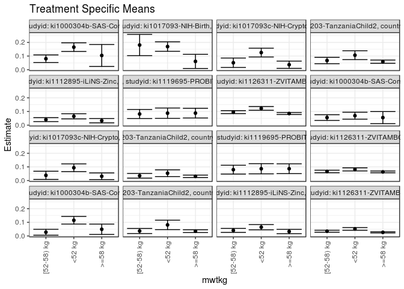

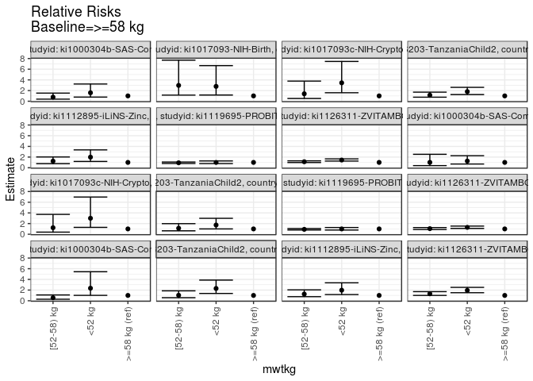

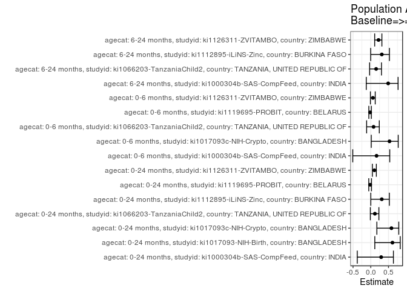

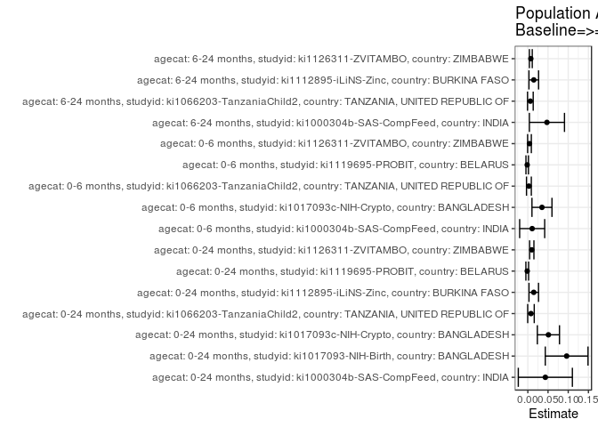

## Results Table

### Parameter: TSM

| agecat | studyid | country | intervention_level | baseline_level | estimate | ci_lower | ci_upper |
| --- | --- | --- | --- | --- | --- | --- | --- |
| 0-24 months | ki1000304b-SAS-CompFeed | INDIA | >=58 kg | NA | 0.1042860 | 0.0237692 | 0.1848029 |
| 0-24 months | ki1000304b-SAS-CompFeed | INDIA | <52 kg | NA | 0.1654028 | 0.1337494 | 0.1970562 |
| 0-24 months | ki1000304b-SAS-CompFeed | INDIA | [52-58) kg | NA | 0.0803906 | 0.0526381 | 0.1081431 |
| 0-24 months | ki1017093-NIH-Birth | BANGLADESH | >=58 kg | NA | 0.0609756 | 0.0091427 | 0.1128086 |
| 0-24 months | ki1017093-NIH-Birth | BANGLADESH | <52 kg | NA | 0.1696429 | 0.1348606 | 0.2044251 |
| 0-24 months | ki1017093-NIH-Birth | BANGLADESH | [52-58) kg | NA | 0.1808511 | 0.1029803 | 0.2587218 |
| 0-24 months | ki1017093c-NIH-Crypto | BANGLADESH | >=58 kg | NA | 0.0364583 | 0.0099295 | 0.0629872 |
| 0-24 months | ki1017093c-NIH-Crypto | BANGLADESH | <52 kg | NA | 0.1256158 | 0.0933571 | 0.1578744 |
| 0-24 months | ki1017093c-NIH-Crypto | BANGLADESH | [52-58) kg | NA | 0.0509554 | 0.0165343 | 0.0853765 |
| 0-24 months | ki1066203-TanzaniaChild2 | TANZANIA, UNITED REPUBLIC OF | >=58 kg | NA | 0.0589867 | 0.0469421 | 0.0710314 |
| 0-24 months | ki1066203-TanzaniaChild2 | TANZANIA, UNITED REPUBLIC OF | <52 kg | NA | 0.1063687 | 0.0741105 | 0.1386270 |
| 0-24 months | ki1066203-TanzaniaChild2 | TANZANIA, UNITED REPUBLIC OF | [52-58) kg | NA | 0.0671680 | 0.0438189 | 0.0905172 |
| 0-24 months | ki1112895-iLiNS-Zinc | BURKINA FASO | >=58 kg | NA | 0.0325527 | 0.0165720 | 0.0485335 |
| 0-24 months | ki1112895-iLiNS-Zinc | BURKINA FASO | <52 kg | NA | 0.0646588 | 0.0457157 | 0.0836020 |
| 0-24 months | ki1112895-iLiNS-Zinc | BURKINA FASO | [52-58) kg | NA | 0.0403612 | 0.0258801 | 0.0548423 |
| 0-24 months | ki1119695-PROBIT | BELARUS | >=58 kg | NA | 0.0879595 | 0.0522911 | 0.1236280 |
| 0-24 months | ki1119695-PROBIT | BELARUS | <52 kg | NA | 0.0875594 | 0.0497356 | 0.1253832 |
| 0-24 months | ki1119695-PROBIT | BELARUS | [52-58) kg | NA | 0.0815722 | 0.0485397 | 0.1146047 |
| 0-24 months | ki1126311-ZVITAMBO | ZIMBABWE | >=58 kg | NA | 0.0849157 | 0.0776947 | 0.0921367 |
| 0-24 months | ki1126311-ZVITAMBO | ZIMBABWE | <52 kg | NA | 0.1226405 | 0.1089578 | 0.1363232 |
| 0-24 months | ki1126311-ZVITAMBO | ZIMBABWE | [52-58) kg | NA | 0.0953552 | 0.0844151 | 0.1062954 |
| 0-6 months | ki1000304b-SAS-CompFeed | INDIA | >=58 kg | NA | 0.0550459 | 0.0107599 | 0.0993318 |
| 0-6 months | ki1000304b-SAS-CompFeed | INDIA | <52 kg | NA | 0.0689354 | 0.0433827 | 0.0944882 |
| 0-6 months | ki1000304b-SAS-CompFeed | INDIA | [52-58) kg | NA | 0.0553191 | 0.0343529 | 0.0762854 |
| 0-6 months | ki1017093c-NIH-Crypto | BANGLADESH | >=58 kg | NA | 0.0312500 | 0.0066227 | 0.0558773 |
| 0-6 months | ki1017093c-NIH-Crypto | BANGLADESH | <52 kg | NA | 0.0935961 | 0.0652454 | 0.1219467 |
| 0-6 months | ki1017093c-NIH-Crypto | BANGLADESH | [52-58) kg | NA | 0.0382166 | 0.0082076 | 0.0682255 |
| 0-6 months | ki1066203-TanzaniaChild2 | TANZANIA, UNITED REPUBLIC OF | >=58 kg | NA | 0.0309445 | 0.0219921 | 0.0398970 |
| 0-6 months | ki1066203-TanzaniaChild2 | TANZANIA, UNITED REPUBLIC OF | <52 kg | NA | 0.0534409 | 0.0286636 | 0.0782182 |
| 0-6 months | ki1066203-TanzaniaChild2 | TANZANIA, UNITED REPUBLIC OF | [52-58) kg | NA | 0.0348825 | 0.0179380 | 0.0518271 |
| 0-6 months | ki1119695-PROBIT | BELARUS | >=58 kg | NA | 0.0865982 | 0.0506651 | 0.1225313 |
| 0-6 months | ki1119695-PROBIT | BELARUS | <52 kg | NA | 0.0864268 | 0.0492070 | 0.1236466 |
| 0-6 months | ki1119695-PROBIT | BELARUS | [52-58) kg | NA | 0.0797516 | 0.0473723 | 0.1121309 |
| 0-6 months | ki1126311-ZVITAMBO | ZIMBABWE | >=58 kg | NA | 0.0633991 | 0.0570584 | 0.0697398 |
| 0-6 months | ki1126311-ZVITAMBO | ZIMBABWE | <52 kg | NA | 0.0818078 | 0.0704161 | 0.0931995 |
| 0-6 months | ki1126311-ZVITAMBO | ZIMBABWE | [52-58) kg | NA | 0.0666466 | 0.0573147 | 0.0759784 |
| 6-24 months | ki1000304b-SAS-CompFeed | INDIA | >=58 kg | NA | 0.0490196 | 0.0111658 | 0.0868735 |
| 6-24 months | ki1000304b-SAS-CompFeed | INDIA | <52 kg | NA | 0.1150943 | 0.0870550 | 0.1431337 |
| 6-24 months | ki1000304b-SAS-CompFeed | INDIA | [52-58) kg | NA | 0.0273973 | 0.0057214 | 0.0490731 |
| 6-24 months | ki1066203-TanzaniaChild2 | TANZANIA, UNITED REPUBLIC OF | >=58 kg | NA | 0.0351867 | 0.0249688 | 0.0454046 |
| 6-24 months | ki1066203-TanzaniaChild2 | TANZANIA, UNITED REPUBLIC OF | <52 kg | NA | 0.0810592 | 0.0462264 | 0.1158920 |
| 6-24 months | ki1066203-TanzaniaChild2 | TANZANIA, UNITED REPUBLIC OF | [52-58) kg | NA | 0.0362688 | 0.0176788 | 0.0548588 |
| 6-24 months | ki1112895-iLiNS-Zinc | BURKINA FASO | >=58 kg | NA | 0.0325122 | 0.0164147 | 0.0486097 |
| 6-24 months | ki1112895-iLiNS-Zinc | BURKINA FASO | <52 kg | NA | 0.0642368 | 0.0450149 | 0.0834586 |
| 6-24 months | ki1112895-iLiNS-Zinc | BURKINA FASO | [52-58) kg | NA | 0.0407207 | 0.0260511 | 0.0553902 |
| 6-24 months | ki1126311-ZVITAMBO | ZIMBABWE | >=58 kg | NA | 0.0265103 | 0.0220409 | 0.0309796 |
| 6-24 months | ki1126311-ZVITAMBO | ZIMBABWE | <52 kg | NA | 0.0515051 | 0.0416042 | 0.0614060 |
| 6-24 months | ki1126311-ZVITAMBO | ZIMBABWE | [52-58) kg | NA | 0.0346545 | 0.0274948 | 0.0418141 |

### Parameter: E(Y)

| agecat | studyid | country | intervention_level | baseline_level | estimate | ci_lower | ci_upper |
| --- | --- | --- | --- | --- | --- | --- | --- |
| 0-24 months | ki1000304b-SAS-CompFeed | INDIA | NA | NA | 0.1476286 | 0.1184599 | 0.1767973 |
| 0-24 months | ki1017093-NIH-Birth | BANGLADESH | NA | NA | 0.1570513 | 0.1284803 | 0.1856223 |
| 0-24 months | ki1017093c-NIH-Crypto | BANGLADESH | NA | NA | 0.0874172 | 0.0672569 | 0.1075775 |
| 0-24 months | ki1066203-TanzaniaChild2 | TANZANIA, UNITED REPUBLIC OF | NA | NA | 0.0667517 | 0.0566626 | 0.0768408 |
| 0-24 months | ki1112895-iLiNS-Zinc | BURKINA FASO | NA | NA | 0.0471995 | 0.0353423 | 0.0590566 |
| 0-24 months | ki1119695-PROBIT | BELARUS | NA | NA | 0.0864798 | 0.0514908 | 0.1214689 |
| 0-24 months | ki1126311-ZVITAMBO | ZIMBABWE | NA | NA | 0.0946454 | 0.0892162 | 0.1000747 |
| 0-6 months | ki1000304b-SAS-CompFeed | INDIA | NA | NA | 0.0657718 | 0.0426648 | 0.0888788 |
| 0-6 months | ki1017093c-NIH-Crypto | BANGLADESH | NA | NA | 0.0662252 | 0.0484753 | 0.0839750 |
| 0-6 months | ki1066203-TanzaniaChild2 | TANZANIA, UNITED REPUBLIC OF | NA | NA | 0.0335884 | 0.0263056 | 0.0408712 |
| 0-6 months | ki1119695-PROBIT | BELARUS | NA | NA | 0.0850276 | 0.0499104 | 0.1201448 |
| 0-6 months | ki1126311-ZVITAMBO | ZIMBABWE | NA | NA | 0.0674703 | 0.0628071 | 0.0721335 |
| 6-24 months | ki1000304b-SAS-CompFeed | INDIA | NA | NA | 0.0963070 | 0.0722853 | 0.1203288 |
| 6-24 months | ki1066203-TanzaniaChild2 | TANZANIA, UNITED REPUBLIC OF | NA | NA | 0.0414560 | 0.0326689 | 0.0502431 |
| 6-24 months | ki1112895-iLiNS-Zinc | BURKINA FASO | NA | NA | 0.0471995 | 0.0353423 | 0.0590566 |
| 6-24 months | ki1126311-ZVITAMBO | ZIMBABWE | NA | NA | 0.0339175 | 0.0303150 | 0.0375200 |

### Parameter: RR

| agecat | studyid | country | intervention_level | baseline_level | estimate | ci_lower | ci_upper |
| --- | --- | --- | --- | --- | --- | --- | --- |
| 0-24 months | ki1000304b-SAS-CompFeed | INDIA | >=58 kg | >=58 kg | 1.0000000 | 1.0000000 | 1.000000 |
| 0-24 months | ki1000304b-SAS-CompFeed | INDIA | <52 kg | >=58 kg | 1.5860493 | 0.7794856 | 3.227195 |
| 0-24 months | ki1000304b-SAS-CompFeed | INDIA | [52-58) kg | >=58 kg | 0.7708662 | 0.3906643 | 1.521088 |
| 0-24 months | ki1017093-NIH-Birth | BANGLADESH | >=58 kg | >=58 kg | 1.0000000 | 1.0000000 | 1.000000 |
| 0-24 months | ki1017093-NIH-Birth | BANGLADESH | <52 kg | >=58 kg | 2.7821429 | 1.1604223 | 6.670261 |
| 0-24 months | ki1017093-NIH-Birth | BANGLADESH | [52-58) kg | >=58 kg | 2.9659574 | 1.1437460 | 7.691309 |
| 0-24 months | ki1017093c-NIH-Crypto | BANGLADESH | >=58 kg | >=58 kg | 1.0000000 | 1.0000000 | 1.000000 |
| 0-24 months | ki1017093c-NIH-Crypto | BANGLADESH | <52 kg | >=58 kg | 3.4454609 | 1.5926859 | 7.453573 |
| 0-24 months | ki1017093c-NIH-Crypto | BANGLADESH | [52-58) kg | >=58 kg | 1.3976342 | 0.5178396 | 3.772175 |
| 0-24 months | ki1066203-TanzaniaChild2 | TANZANIA, UNITED REPUBLIC OF | >=58 kg | >=58 kg | 1.0000000 | 1.0000000 | 1.000000 |
| 0-24 months | ki1066203-TanzaniaChild2 | TANZANIA, UNITED REPUBLIC OF | <52 kg | >=58 kg | 1.8032659 | 1.2509990 | 2.599337 |
| 0-24 months | ki1066203-TanzaniaChild2 | TANZANIA, UNITED REPUBLIC OF | [52-58) kg | >=58 kg | 1.1386979 | 0.7608628 | 1.704161 |
| 0-24 months | ki1112895-iLiNS-Zinc | BURKINA FASO | >=58 kg | >=58 kg | 1.0000000 | 1.0000000 | 1.000000 |
| 0-24 months | ki1112895-iLiNS-Zinc | BURKINA FASO | <52 kg | >=58 kg | 1.9862788 | 1.1791542 | 3.345876 |
| 0-24 months | ki1112895-iLiNS-Zinc | BURKINA FASO | [52-58) kg | >=58 kg | 1.2398709 | 0.7616227 | 2.018427 |
| 0-24 months | ki1119695-PROBIT | BELARUS | >=58 kg | >=58 kg | 1.0000000 | 1.0000000 | 1.000000 |
| 0-24 months | ki1119695-PROBIT | BELARUS | <52 kg | >=58 kg | 0.9954508 | 0.7794503 | 1.271309 |
| 0-24 months | ki1119695-PROBIT | BELARUS | [52-58) kg | >=58 kg | 0.9273830 | 0.7982058 | 1.077466 |
| 0-24 months | ki1126311-ZVITAMBO | ZIMBABWE | >=58 kg | >=58 kg | 1.0000000 | 1.0000000 | 1.000000 |
| 0-24 months | ki1126311-ZVITAMBO | ZIMBABWE | <52 kg | >=58 kg | 1.4442620 | 1.2551655 | 1.661847 |
| 0-24 months | ki1126311-ZVITAMBO | ZIMBABWE | [52-58) kg | >=58 kg | 1.1229397 | 0.9734232 | 1.295422 |
| 0-6 months | ki1000304b-SAS-CompFeed | INDIA | >=58 kg | >=58 kg | 1.0000000 | 1.0000000 | 1.000000 |
| 0-6 months | ki1000304b-SAS-CompFeed | INDIA | <52 kg | >=58 kg | 1.2523269 | 0.6960862 | 2.253058 |
| 0-6 months | ki1000304b-SAS-CompFeed | INDIA | [52-58) kg | >=58 kg | 1.0049645 | 0.4012309 | 2.517139 |
| 0-6 months | ki1017093c-NIH-Crypto | BANGLADESH | >=58 kg | >=58 kg | 1.0000000 | 1.0000000 | 1.000000 |
| 0-6 months | ki1017093c-NIH-Crypto | BANGLADESH | <52 kg | >=58 kg | 2.9950739 | 1.2874825 | 6.967448 |
| 0-6 months | ki1017093c-NIH-Crypto | BANGLADESH | [52-58) kg | >=58 kg | 1.2229299 | 0.4020223 | 3.720086 |
| 0-6 months | ki1066203-TanzaniaChild2 | TANZANIA, UNITED REPUBLIC OF | >=58 kg | >=58 kg | 1.0000000 | 1.0000000 | 1.000000 |
| 0-6 months | ki1066203-TanzaniaChild2 | TANZANIA, UNITED REPUBLIC OF | <52 kg | >=58 kg | 1.7269900 | 0.9996537 | 2.983528 |
| 0-6 months | ki1066203-TanzaniaChild2 | TANZANIA, UNITED REPUBLIC OF | [52-58) kg | >=58 kg | 1.1272595 | 0.6405198 | 1.983879 |
| 0-6 months | ki1119695-PROBIT | BELARUS | >=58 kg | >=58 kg | 1.0000000 | 1.0000000 | 1.000000 |
| 0-6 months | ki1119695-PROBIT | BELARUS | <52 kg | >=58 kg | 0.9980207 | 0.7885023 | 1.263212 |
| 0-6 months | ki1119695-PROBIT | BELARUS | [52-58) kg | >=58 kg | 0.9209380 | 0.7936094 | 1.068696 |
| 0-6 months | ki1126311-ZVITAMBO | ZIMBABWE | >=58 kg | >=58 kg | 1.0000000 | 1.0000000 | 1.000000 |
| 0-6 months | ki1126311-ZVITAMBO | ZIMBABWE | <52 kg | >=58 kg | 1.2903634 | 1.0870088 | 1.531761 |
| 0-6 months | ki1126311-ZVITAMBO | ZIMBABWE | [52-58) kg | >=58 kg | 1.0512234 | 0.8849937 | 1.248676 |
| 6-24 months | ki1000304b-SAS-CompFeed | INDIA | >=58 kg | >=58 kg | 1.0000000 | 1.0000000 | 1.000000 |
| 6-24 months | ki1000304b-SAS-CompFeed | INDIA | <52 kg | >=58 kg | 2.3479245 | 1.0137636 | 5.437904 |
| 6-24 months | ki1000304b-SAS-CompFeed | INDIA | [52-58) kg | >=58 kg | 0.5589041 | 0.2872384 | 1.087507 |
| 6-24 months | ki1066203-TanzaniaChild2 | TANZANIA, UNITED REPUBLIC OF | >=58 kg | >=58 kg | 1.0000000 | 1.0000000 | 1.000000 |
| 6-24 months | ki1066203-TanzaniaChild2 | TANZANIA, UNITED REPUBLIC OF | <52 kg | >=58 kg | 2.3036879 | 1.3713463 | 3.869904 |
| 6-24 months | ki1066203-TanzaniaChild2 | TANZANIA, UNITED REPUBLIC OF | [52-58) kg | >=58 kg | 1.0307524 | 0.5718773 | 1.857829 |
| 6-24 months | ki1112895-iLiNS-Zinc | BURKINA FASO | >=58 kg | >=58 kg | 1.0000000 | 1.0000000 | 1.000000 |
| 6-24 months | ki1112895-iLiNS-Zinc | BURKINA FASO | <52 kg | >=58 kg | 1.9757716 | 1.1627978 | 3.357139 |
| 6-24 months | ki1112895-iLiNS-Zinc | BURKINA FASO | [52-58) kg | >=58 kg | 1.2524720 | 0.7674463 | 2.044033 |
| 6-24 months | ki1126311-ZVITAMBO | ZIMBABWE | >=58 kg | >=58 kg | 1.0000000 | 1.0000000 | 1.000000 |
| 6-24 months | ki1126311-ZVITAMBO | ZIMBABWE | <52 kg | >=58 kg | 1.9428340 | 1.5045218 | 2.508840 |
| 6-24 months | ki1126311-ZVITAMBO | ZIMBABWE | [52-58) kg | >=58 kg | 1.3072088 | 1.0012249 | 1.706704 |

### Parameter: PAR

| agecat | studyid | country | intervention_level | baseline_level | estimate | ci_lower | ci_upper |
| --- | --- | --- | --- | --- | --- | --- | --- |
| 0-24 months | ki1000304b-SAS-CompFeed | INDIA | >=58 kg | NA | 0.0433426 | -0.0235763 | 0.1102614 |
| 0-24 months | ki1017093-NIH-Birth | BANGLADESH | >=58 kg | NA | 0.0960757 | 0.0431904 | 0.1489609 |
| 0-24 months | ki1017093c-NIH-Crypto | BANGLADESH | >=58 kg | NA | 0.0509589 | 0.0235314 | 0.0783864 |
| 0-24 months | ki1066203-TanzaniaChild2 | TANZANIA, UNITED REPUBLIC OF | >=58 kg | NA | 0.0077650 | -0.0003128 | 0.0158428 |
| 0-24 months | ki1112895-iLiNS-Zinc | BURKINA FASO | >=58 kg | NA | 0.0146468 | 0.0028454 | 0.0264481 |
| 0-24 months | ki1119695-PROBIT | BELARUS | >=58 kg | NA | -0.0014797 | -0.0048572 | 0.0018978 |
| 0-24 months | ki1126311-ZVITAMBO | ZIMBABWE | >=58 kg | NA | 0.0097297 | 0.0044071 | 0.0150523 |
| 0-6 months | ki1000304b-SAS-CompFeed | INDIA | >=58 kg | NA | 0.0107259 | -0.0202489 | 0.0417008 |
| 0-6 months | ki1017093c-NIH-Crypto | BANGLADESH | >=58 kg | NA | 0.0349752 | 0.0102146 | 0.0597358 |
| 0-6 months | ki1066203-TanzaniaChild2 | TANZANIA, UNITED REPUBLIC OF | >=58 kg | NA | 0.0026439 | -0.0033366 | 0.0086244 |
| 0-6 months | ki1119695-PROBIT | BELARUS | >=58 kg | NA | -0.0015706 | -0.0046652 | 0.0015240 |
| 0-6 months | ki1126311-ZVITAMBO | ZIMBABWE | >=58 kg | NA | 0.0040712 | -0.0005180 | 0.0086605 |
| 6-24 months | ki1000304b-SAS-CompFeed | INDIA | >=58 kg | NA | 0.0472874 | 0.0038433 | 0.0907315 |
| 6-24 months | ki1066203-TanzaniaChild2 | TANZANIA, UNITED REPUBLIC OF | >=58 kg | NA | 0.0062693 | -0.0007425 | 0.0132811 |
| 6-24 months | ki1112895-iLiNS-Zinc | BURKINA FASO | >=58 kg | NA | 0.0146873 | 0.0027615 | 0.0266130 |
| 6-24 months | ki1126311-ZVITAMBO | ZIMBABWE | >=58 kg | NA | 0.0074072 | 0.0038827 | 0.0109318 |

### Parameter: PAF

| agecat | studyid | country | intervention_level | baseline_level | estimate | ci_lower | ci_upper |
| --- | --- | --- | --- | --- | --- | --- | --- |
| 0-24 months | ki1000304b-SAS-CompFeed | INDIA | >=58 kg | NA | 0.2935919 | -0.3812690 | 0.6387290 |
| 0-24 months | ki1017093-NIH-Birth | BANGLADESH | >=58 kg | NA | 0.6117471 | 0.1133348 | 0.8299919 |
| 0-24 months | ki1017093c-NIH-Crypto | BANGLADESH | >=58 kg | NA | 0.5829388 | 0.1719680 | 0.7899356 |
| 0-24 months | ki1066203-TanzaniaChild2 | TANZANIA, UNITED REPUBLIC OF | >=58 kg | NA | 0.1163265 | -0.0121054 | 0.2284610 |
| 0-24 months | ki1112895-iLiNS-Zinc | BURKINA FASO | >=58 kg | NA | 0.3103159 | 0.0013383 | 0.5236984 |
| 0-24 months | ki1119695-PROBIT | BELARUS | >=58 kg | NA | -0.0171105 | -0.0564464 | 0.0207608 |
| 0-24 months | ki1126311-ZVITAMBO | ZIMBABWE | >=58 kg | NA | 0.1028018 | 0.0450512 | 0.1570599 |
| 0-6 months | ki1000304b-SAS-CompFeed | INDIA | >=58 kg | NA | 0.1630781 | -0.5077606 | 0.5354446 |
| 0-6 months | ki1017093c-NIH-Crypto | BANGLADESH | >=58 kg | NA | 0.5281250 | 0.0134939 | 0.7742883 |
| 0-6 months | ki1066203-TanzaniaChild2 | TANZANIA, UNITED REPUBLIC OF | >=58 kg | NA | 0.0787147 | -0.1166381 | 0.2398910 |
| 0-6 months | ki1119695-PROBIT | BELARUS | >=58 kg | NA | -0.0184717 | -0.0545823 | 0.0164023 |
| 0-6 months | ki1126311-ZVITAMBO | ZIMBABWE | >=58 kg | NA | 0.0603413 | -0.0100645 | 0.1258395 |
| 6-24 months | ki1000304b-SAS-CompFeed | INDIA | >=58 kg | NA | 0.4910069 | -0.1275242 | 0.7702276 |
| 6-24 months | ki1066203-TanzaniaChild2 | TANZANIA, UNITED REPUBLIC OF | >=58 kg | NA | 0.1512275 | -0.0326517 | 0.3023643 |
| 6-24 months | ki1112895-iLiNS-Zinc | BURKINA FASO | >=58 kg | NA | 0.3111740 | -0.0020068 | 0.5264690 |
| 6-24 months | ki1126311-ZVITAMBO | ZIMBABWE | >=58 kg | NA | 0.2183899 | 0.1099802 | 0.3135946 |